# Data cleaning and preprocessing

```python
import pandas as pd
import numpy as np
```

#### Dataset loading

```python
df = pd.read_csv("Ecommerce_dataset.csv")
```

#### Explore the dataset

```python
df.head()
```

|  | UserID | UserName | Age | Gender | Country | SignUpDate | ProductID | ProductName | Category | Price | ... | Quantity | TotalAmount | HasDiscountApplied | DiscountRate | ReviewScore | ReviewText | LastLogin | SessionDuration | DeviceType | ReferralSource |
| --- | --- | --- | --- | --- | --- | --- | --- | --- | --- | --- | --- | --- | --- | --- | --- | --- | --- | --- | --- | --- | --- |
| 0 | 1.0 | User_1 | 39.0 | Male | UK | 2021-02-01 | 8190.0 | Shoes | Books | 532.37 | ... | 1.0 | 532.37 | False | 0.02 | 5.1 | Excellent | 2024-05-03 04:04:27.591583 | 45.02 | Mobile | Social Media |
| 1 | 2.0 | User_2 | 25.0 | Female | Canada | 2020-12-04 | 9527.0 | T-shirt | Accessories | 848.83 | ... | 1.0 | 848.83 | True | 0.29 | 5.1 | Excellent | 2024-08-31 04:04:27.591606 | 13.83 | Mobile | Social Media |
| 2 | 3.0 | User_3 | 43.0 | NaN | Canada | 2022-07-08 | 3299.0 | Headphones | Apparel | 64.88 | ... | 2.0 | 129.76 | False | 0.03 | 3.2 | Good | 2024-07-28 04:04:27.591611 | 59.09 | Tablet | Organic Search |
| 3 | 4.0 | User_4 | 44.0 | Male | Germany | 2021-06-07 | 8795.0 | T-shirt | Apparel | 465.08 | ... | 2.0 | 930.16 | False | 0.23 | 4.3 | Good | 2024-03-11 04:04:27.591615 | 55.42 | Desktop | Email Marketing |
| 4 | 5.0 | User_5 | 23.0 | Female | Canada | 2021-11-06 | 1389.0 | Shoes | Books | 331.82 | ... | 1.0 | 331.82 | False | 0.02 | 5.1 | Average | 2024-07-02 04:04:27.591619 | 14.99 | Tablet | Email Marketing |

5 rows × 21 columns

```python
df.shape
```

```
(101432, 21)
```

```python
df.info()
```

```
<class 'pandas.core.frame.DataFrame'>
RangeIndex: 101432 entries, 0 to 101431
Data columns (total 21 columns):
 #   Column              Non-Null Count   Dtype
---  ------              --------------   -----
 0   UserID              99441 non-null   float64
 1   UserName            98521 non-null   object
 2   Age                 99870 non-null   float64
 3   Gender              100476 non-null  object
 4   Country             100874 non-null  object
 5   SignUpDate          101432 non-null  object
 6   ProductID           99051 non-null   float64
 7   ProductName         100070 non-null  object
 8   Category            98206 non-null   object
 9   Price               98719 non-null   float64
 10  PurchaseDate        101432 non-null  object
 11  Quantity            99977 non-null   float64
 12  TotalAmount         98761 non-null   float64
 13  HasDiscountApplied  100686 non-null  object
 14  DiscountRate        100114 non-null  float64
 15  ReviewScore         98860 non-null   float64
 16  ReviewText          100579 non-null  object
 17  LastLogin           101432 non-null  object
 18  SessionDuration     98185 non-null   float64
 19  DeviceType          99738 non-null   object
 20  ReferralSource      98930 non-null   object
dtypes: float64(9), object(12)
memory usage: 16.3+ MB
```

```python
df.describe()
```

|  | UserID | Age | ProductID | Price | Quantity | TotalAmount | DiscountRate | ReviewScore | SessionDuration |
| --- | --- | --- | --- | --- | --- | --- | --- | --- | --- |
| count | 99441.000000 | 99870.000000 | 99051.000000 | 98719.000000 | 99977.000000 | 98761.000000 | 100114.000000 | 98860.000000 | 98185.000000 |
| mean | 49974.085749 | 43.455002 | 5508.661235 | 505.599977 | 2.496134 | 1262.115243 | 0.249931 | 4.005669 | 62.492989 |
| std | 28880.769418 | 14.979712 | 2606.128171 | 286.216451 | 1.120575 | 964.744379 | 0.144524 | 0.999593 | 35.624974 |
| min | 1.000000 | 18.000000 | 1000.000000 | 10.000000 | 1.000000 | 10.020000 | 0.000000 | -0.600000 | 5.000000 |
| 25% | 24971.000000 | 31.000000 | 3227.500000 | 257.100000 | 1.000000 | 495.660000 | 0.130000 | 3.300000 | 33.750000 |
| 50% | 49961.000000 | 43.000000 | 5523.000000 | 505.750000 | 2.000000 | 967.060000 | 0.250000 | 4.000000 | 62.400000 |
| 75% | 74992.000000 | 56.000000 | 7776.000000 | 753.740000 | 4.000000 | 1852.650000 | 0.380000 | 4.700000 | 91.030000 |
| max | 100000.000000 | 69.000000 | 9998.000000 | 999.980000 | 4.000000 | 3999.720000 | 0.500000 | 8.600000 | 3000.000000 |

#### Check missing values

```python
print(df.isnull().sum())
```

```
UserID                1991
UserName              2911
Age                   1562
Gender                 956
Country                558
SignUpDate               0
ProductID             2381
ProductName           1362
Category              3226
Price                 2713
PurchaseDate             0
Quantity              1455
TotalAmount           2671
HasDiscountApplied     746
DiscountRate          1318
ReviewScore           2572
ReviewText             853
LastLogin                0
SessionDuration       3247
DeviceType            1694
ReferralSource        2502
dtype: int64
```

#### Convert data types

```python
num_cols = ['Age','Price','Quantity','TotalAmount','DiscountRate','ReviewScore','SessionDuration']
for col in num_cols:
    df[col] = pd.to_numeric(df[col], errors='coerce')

date_cols = ['SignUpDate','PurchaseDate']
for col in date_cols:
    df[col] = pd.to_datetime(df[col], format='%Y-%m-%d', errors='coerce')

df['LastLogin'] = df['LastLogin'].astype(str).str.strip()
df['LastLogin'] = df['LastLogin'].str.replace(r'[^0-9:\.]', '', regex=True)
df['LastLogin'] = pd.to_timedelta(df['LastLogin'])
```

```python
print(df.isnull().sum())
```

```
UserID                1991
UserName              2911
Age                   1562
Gender                 956
Country                558
SignUpDate               0
ProductID             2381
ProductName           1362
Category              3226
Price                 2713
PurchaseDate             0
Quantity              1455
TotalAmount           2671
HasDiscountApplied     746
DiscountRate          1318
ReviewScore           2572
ReviewText             853
LastLogin                0
SessionDuration       3247
DeviceType            1694
ReferralSource        2502
dtype: int64
```

##### Price based on Category + ProductName

```python
df['Price'] = df.groupby(['Category','ProductName'])['Price'].transform(lambda x: x.fillna(x.median()))
```

##### Quantity based on ProductName

```python
df['Quantity'] = df.groupby('ProductName')['Quantity'].transform(lambda x: x.fillna(x.median()))
```

##### Age based on Gender

```python
df['Age'] = df.groupby('Gender')['Age'].transform(lambda x: x.fillna(x.median()))
```

##### SessionDuration based on DeviceType

```python
df['SessionDuration'] = df.groupby('DeviceType')['SessionDuration'].transform(lambda x: x.fillna(x.median()))
```

##### DiscountRate based on Category

```python
df['DiscountRate'] = df.groupby('Category')['DiscountRate'].transform(lambda x: x.fillna(x.median()))
```

##### ReviewScore based on ProductName

```python
df['ReviewScore'] = df.groupby('ProductName')['ReviewScore'].transform(lambda x: x.fillna(x.median()))
```

##### Category based on ProductName

```python
df['Category'] = df.groupby('ProductName')['Category'].transform(lambda x: x.fillna(x.mode()[0] if not x.mode().empty else "Unknown"))
```

##### DeviceType based on UserID

```python
df['DeviceType'] = df.groupby('UserID')['DeviceType'].transform(lambda x: x.fillna(x.mode()[0] if not x.mode().empty else "Unknown"))
```

##### Country based on ReferralSource

```python
df['Country'] = df.groupby('ReferralSource')['Country'].transform(lambda x: x.fillna(x.mode()[0] if not x.mode().empty else "Unknown"))
```

#### Fill Numerical and Categorical Columns

```python
pd.set_option('future.no_silent_downcasting', True)
# Numerical
for col in num_cols:
    df[col] = df[col].fillna(df[col].median())

# Categorical
cat_cols = ['UserName','Gender','Country','ProductName','Category',
            'DeviceType','ReferralSource','HasDiscountApplied']

for col in cat_cols:
    if not df[col].mode().empty:
        df[col] = df[col].fillna(df[col].mode()[0])
```

#### Compute Missing TotalAmount

```python
df['TotalAmount'] = df['TotalAmount'].fillna(df['Price'] * df['Quantity'])
```

#### Fill Missing Values

```python
df['UserID'] = df['UserID'].ffill()
df['ProductID'] = df['ProductID'].ffill()

for col in date_cols:
    df[col] = df[col].ffill()
```

#### check duplicates

```python
print(df.duplicated().sum())
```

```
1366
```

#### Remove duplicates

```python
df.drop_duplicates(inplace=True)
```

```python
print(df.duplicated().sum())
```

```
0
```

#### Clean column names

```python
df.columns = df.columns.str.strip().str.lower().str.replace(" ", "_")
```

```python
df['reviewtext'] = df['reviewtext'].fillna("No Review")
```

```python
print(df.isnull().sum())
```

```
userid                0
username              0
age                   0
gender                0
country               0
signupdate            0
productid             0
productname           0
category              0
price                 0
purchasedate          0
quantity              0
totalamount           0
hasdiscountapplied    0
discountrate          0
reviewscore           0
reviewtext            0
lastlogin             0
sessionduration       0
devicetype            0
referralsource        0
dtype: int64
```

#### Label Encoding

```python
from sklearn.preprocessing import LabelEncoder

le = LabelEncoder()
label_cols = ['gender','category','devicetype','referralsource','country','productname','username']
for col in label_cols:
    df[col] = le.fit_transform(df[col])
```

```python
df.head()
```

[output not shown]

5 rows × 21 columns

#### Outlier Removal

```python
import matplotlib.pyplot as plt
import seaborn as sns
```

##### 01. Calculate Q1, Q3, IQR

```python
cols = ['price','quantity','totalamount','sessionduration']
for col in cols:
    print(f"\n🔹 Processing column: {col}")

    Q1 = df[col].quantile(0.25)
    Q3 = df[col].quantile(0.75)
    IQR = Q3 - Q1
```

```
🔹 Processing column: price

🔹 Processing column: quantity

🔹 Processing column: totalamount

🔹 Processing column: sessionduration
```

##### 02. Define bounds

```python
lower_bound = Q1 - 1.5 * IQR
upper_bound = Q3 + 1.5 * IQR
```

##### 03. Detect outliers

```python
outliers = df[(df[col] < lower_bound) | (df[col] > upper_bound)]
print("Outliers detected:\n", outliers[[col]])
```

```
Outliers detected:
        sessionduration
22183           2000.0
32613           3000.0
55693           1000.0
61655           1500.0
84710           1200.0
```

##### 04. Remove outliers

```python
df_cleaned = df[(df[col] >= lower_bound) & (df[col] <= upper_bound)]
print("Cleaned Data:\n", df_cleaned[[col]])
```

```
Cleaned Data:
         sessionduration
0                 45.02
1                 13.83
2                 59.09
3                 55.42
4                 14.99
...                 ...
101313            90.25
101342            17.56
101373            47.15
101426           110.68
101431            38.79

[100061 rows x 1 columns]
```

##### 05. Plot Boxplots

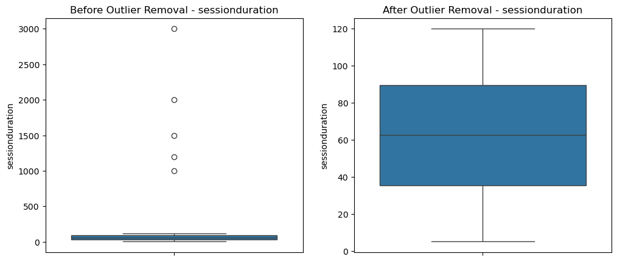

```python
plt.figure(figsize=(12, 5))

# Before Cleaning
plt.subplot(1, 2, 1)
sns.boxplot(y=df[col])
plt.title(f"Before Outlier Removal - {col}")

# After Cleaning
plt.subplot(1, 2, 2)
sns.boxplot(y=df_cleaned[col])
plt.title(f"After Outlier Removal - {col}")

plt.show()
```

#### Log Transformation

```python
cols = ['price', 'totalamount', 'sessionduration']
for col in cols:
    print(f"\n🔹 Processing column: {col}")
    df[f'log_{col}'] = np.log1p(df[col])
```

```
🔹 Processing column: price

🔹 Processing column: totalamount

🔹 Processing column: sessionduration
```

##### Plot Before and After

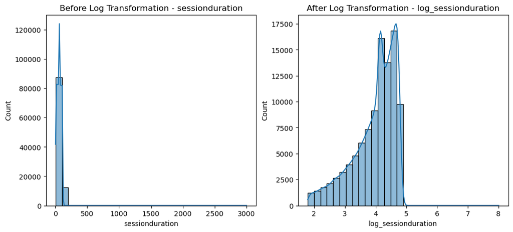

```python
plt.figure(figsize=(12, 5))

# Before Transformation
plt.subplot(1, 2, 1)
sns.histplot(df[col].dropna(), bins=30, kde=True)
plt.title(f"Before Log Transformation - {col}")

# After Transformation
plt.subplot(1, 2, 2)
sns.histplot(df[f'log_{col}'].dropna(), bins=30, kde=True)
plt.title(f"After Log Transformation - log_{col}")

plt.show()
```

##### Display sample

```python
print(df[[ 'price','log_price','totalamount','log_totalamount' ]].head())
```

```
    price  log_price  totalamount  log_totalamount
0  532.37   6.279215       532.37         6.279215
1  848.83   6.745036       848.83         6.745036
2   64.88   4.187835       129.76         4.873364
3  465.08   6.144357       930.16         6.836431
4  331.82   5.807602       331.82         5.807602
```

#### Save the cleaned Dataset

```python
df.to_csv("cleaned_ecommerce_dataset.csv", index=False)
```

# Data Visualization 01

### Import libraries

```python
import pandas as pd
import numpy as np
import matplotlib.pyplot as plt
import seaborn as sns
from mpl_toolkits.axes_grid1.inset_locator import inset_axes
```

### Load the cleaned dataset

```python
df = pd.read_csv("cleaned_ecommerce_dataset.csv")
```

### Sub plots

#### 01.Total Amount,Session Duration,Quantity,Review Score, Discount,Price by age

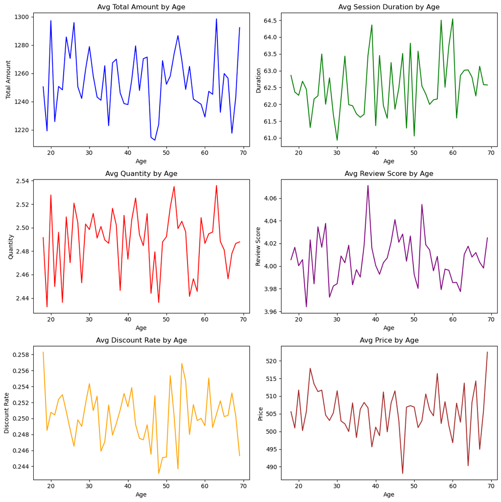

```python
fig, axes = plt.subplots(3, 2, figsize=(12, 12))
colors = ['blue', 'green', 'red', 'purple', 'orange', 'brown']

df_agg = df.groupby('age')['totalamount'].mean().reset_index().sort_values('age')
axes[0, 0].plot(df_agg['age'], df_agg['totalamount'], color=colors[0])
axes[0, 0].set_title("Avg Total Amount by Age")
axes[0, 0].set_xlabel("Age")
axes[0, 0].set_ylabel("Total Amount")

df_agg = df.groupby('age')['sessionduration'].mean().reset_index().sort_values('age')
axes[0, 1].plot(df_agg['age'], df_agg['sessionduration'], color=colors[1])
axes[0, 1].set_title("Avg Session Duration by Age")
axes[0, 1].set_xlabel("Age")
axes[0, 1].set_ylabel("Duration")

df_agg = df.groupby('age')['quantity'].mean().reset_index().sort_values('age')
axes[1, 0].plot(df_agg['age'], df_agg['quantity'], color=colors[2])
axes[1, 0].set_title("Avg Quantity by Age")
axes[1, 0].set_xlabel("Age")
axes[1, 0].set_ylabel("Quantity")

df_agg = df.groupby('age')['reviewscore'].mean().reset_index().sort_values('age')
axes[1, 1].plot(df_agg['age'], df_agg['reviewscore'], color=colors[3])
axes[1, 1].set_title("Avg Review Score by Age")
axes[1, 1].set_xlabel("Age")
axes[1, 1].set_ylabel("Review Score")

df_agg = df.groupby('age')['discountrate'].mean().reset_index().sort_values('age')
axes[2, 0].plot(df_agg['age'], df_agg['discountrate'], color=colors[4])
axes[2, 0].set_title("Avg Discount Rate by Age")
axes[2, 0].set_xlabel("Age")
axes[2, 0].set_ylabel("Discount Rate")

df_agg = df.groupby('age')['price'].mean().reset_index().sort_values('age')
axes[2, 1].plot(df_agg['age'], df_agg['price'], color=colors[5])
axes[2, 1].set_title("Avg Price by Age")
axes[2, 1].set_xlabel("Age")
axes[2, 1].set_ylabel("Price")

plt.tight_layout()
plt.show()
```

#### 02.Total Sales over Time

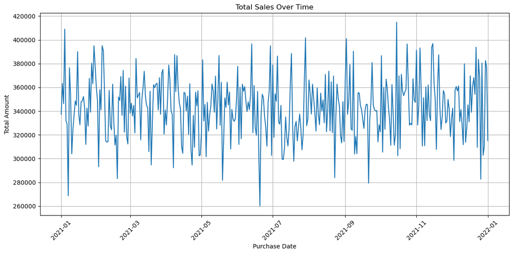

```python
df['purchasedate'] = pd.to_datetime(df['purchasedate'], errors='coerce')
df = df.dropna(subset=['purchasedate', 'totalamount'])
df = df.sort_values('purchasedate')
df_grouped = df.groupby('purchasedate')['totalamount'].sum().reset_index()
fig, ax = plt.subplots(1, 1, figsize=(12, 6))
ax.plot(
    df_grouped['purchasedate'],
    df_grouped['totalamount'],
    linestyle='-'
)

ax.set_xlabel('Purchase Date')
ax.set_ylabel('Total Amount')
ax.set_title('Total Sales Over Time')
ax.tick_params(axis='x', rotation=45)
ax.grid(True)

fig.tight_layout()
plt.show()
```

### Insets

#### 01. Analysis of Customer Behavior, Engagement, and Spending Patterns by Age

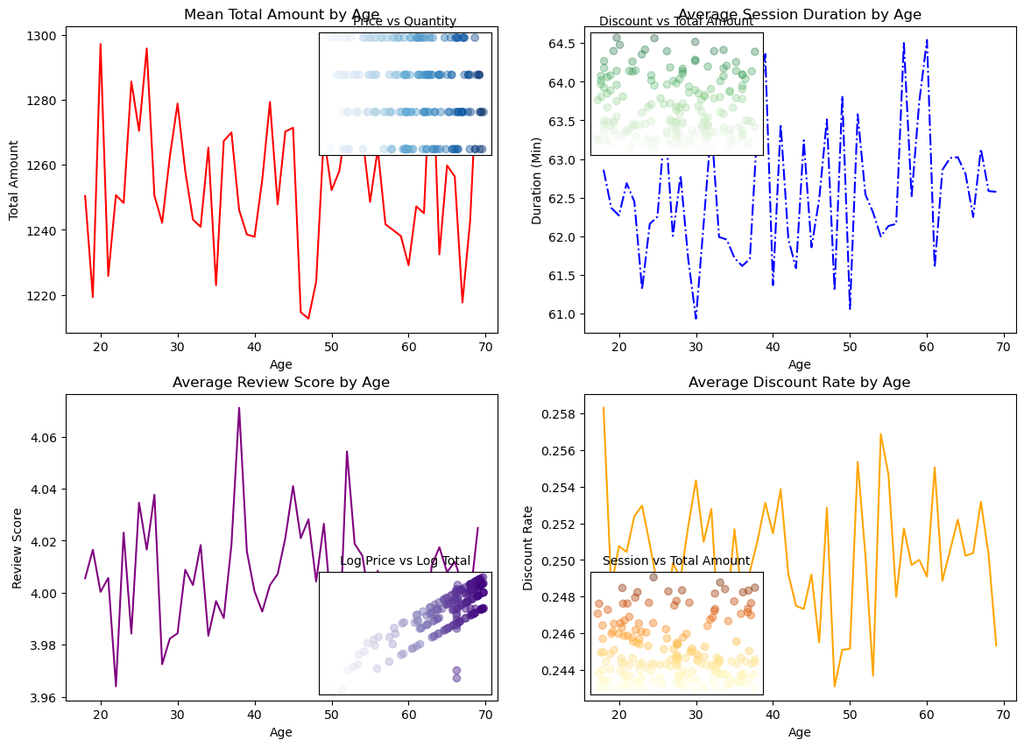

```python
from mpl_toolkits.axes_grid1.inset_locator import inset_axes
import matplotlib.pyplot as plt

fig, axes = plt.subplots(2, 2, figsize=(14, 10))

ax = axes[0, 0]
age_data = df.groupby('age')['totalamount'].mean().reset_index()
ax.plot(age_data['age'], age_data['totalamount'], color='red')
ax.set_title('Mean Total Amount by Age')
ax.set_xlabel('Age')
ax.set_ylabel('Total Amount')

axins = inset_axes(ax, width="40%", height="40%", loc=1)
sample = df.sample(200)
axins.scatter(sample['price'], sample['quantity'], c=sample['price'], cmap='Blues', alpha=0.4)
axins.set_xticks([]); axins.set_yticks([])
axins.set_title('Price vs Quantity', fontsize=10)

ax = axes[0, 1]
age_data = df.groupby('age')['sessionduration'].mean().reset_index()
ax.plot(age_data['age'], age_data['sessionduration'], color='blue', linestyle='-.')
ax.set_title('Average Session Duration by Age')
ax.set_xlabel('Age')
ax.set_ylabel('Duration (Min)')

axins = inset_axes(ax, width="40%", height="40%", loc=2)
sample = df.sample(200)
axins.scatter(sample['discountrate'], sample['totalamount'], c=sample['totalamount'], cmap='Greens', alpha=0.3)
axins.set_xticks([]); axins.set_yticks([])
axins.set_title('Discount vs Total Amount', fontsize=10)

ax = axes[1, 0]
age_data = df.groupby('age')['reviewscore'].mean().reset_index()
ax.plot(age_data['age'], age_data['reviewscore'], color='purple')
ax.set_title('Average Review Score by Age')
ax.set_xlabel('Age')
ax.set_ylabel('Review Score')

axins = inset_axes(ax, width="40%", height="40%", loc=4)
sample = df.sample(200)
axins.scatter(sample['log_price'], sample['log_totalamount'], c=sample['log_price'], cmap='Purples', alpha=0.5)
axins.set_xticks([]); axins.set_yticks([])
axins.set_title('Log Price vs Log Total', fontsize=10)

ax = axes[1, 1]
age_data = df.groupby('age')['discountrate'].mean().reset_index()
ax.plot(age_data['age'], age_data['discountrate'], color='orange')
ax.set_title('Average Discount Rate by Age')
ax.set_xlabel('Age')
ax.set_ylabel('Discount Rate')

axins = inset_axes(ax, width="40%", height="40%", loc=3)
sample = df.sample(200)
axins.scatter(sample['sessionduration'], sample['totalamount'], c=sample['totalamount'], cmap='YlOrBr', alpha=0.4)
axins.set_xticks([]); axins.set_yticks([])
axins.set_title('Session vs Total Amount', fontsize=10)
```

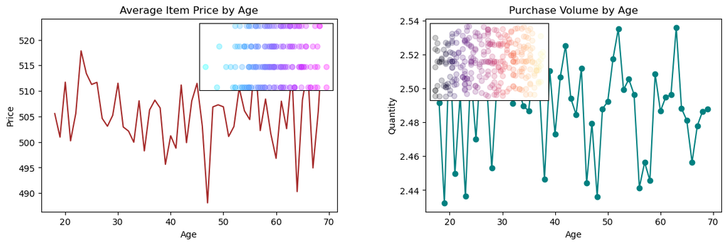

```python
fig, axes = plt.subplots(1, 2, figsize=(14, 4))

ax = axes[0]
age_data = df.groupby('age')['price'].mean().reset_index()
ax.plot(age_data['age'], age_data['price'], color='brown')
ax.set_title('Average Item Price by Age')
ax.set_xlabel('Age')
ax.set_ylabel('Price')
axins = inset_axes(ax, width="45%", height="35%", loc=1)
sample = df.sample(200)
axins.scatter(sample['reviewscore'], sample['quantity'],c=sample['reviewscore'], cmap='cool', alpha=0.3)
axins.set_xticks([])
axins.set_yticks([])


ax = axes[1]
age_data = df.groupby('age')['quantity'].mean().reset_index()
ax.plot(age_data['age'], age_data['quantity'], color='teal', marker='o')
ax.set_title('Purchase Volume by Age')
ax.set_xlabel('Age')
ax.set_ylabel('Quantity')
axins = inset_axes(ax, width="40%", height="40%", loc=2)
sample = df.sample(300)
axins.scatter(sample['age'], sample['sessionduration'], c=sample['age'], cmap='magma', alpha=0.2)
axins.set_xticks([])
axins.set_yticks([])

plt.subplots_adjust(wspace=0.3)
plt.show()
```

#### 07.Mean Total Amount by Purchase Month

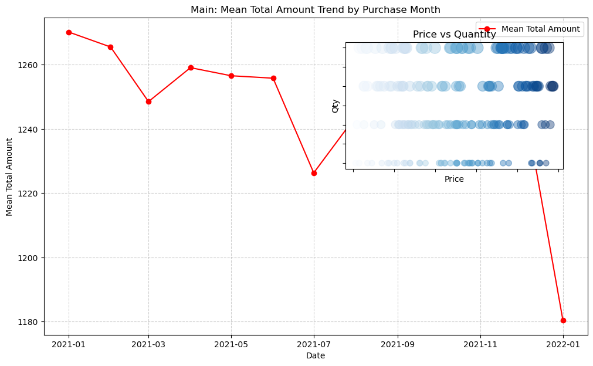

```python
df['purchasedate'] = pd.to_datetime(df['purchasedate'], errors='coerce')
df = df.dropna(subset=['purchasedate'])
date_data = df.groupby(df['purchasedate'].dt.to_period('M'))['totalamount'].mean().reset_index()
date_data['purchasedate'] = date_data['purchasedate'].dt.to_timestamp()

fig, ax = plt.subplots(1, 1, figsize=[10, 6])

plt.tight_layout()

ax.plot(date_data['purchasedate'], date_data['totalamount'],
        label='Mean Total Amount', color='red', marker='o')
ax.set_title('Main: Mean Total Amount Trend by Purchase Month')
ax.set_xlabel('Date')
ax.set_ylabel('Mean Total Amount')
ax.legend()
ax.grid(True, linestyle='--', alpha=0.6)

axins = inset_axes(ax, width="40%", height="40%", loc=1, borderpad=3)
sample = df.sample(200, random_state=42)
x = sample['price']
y = sample['quantity']

axins.scatter(x, y, c=x*0.01, s=y*50, alpha=0.4, cmap='Blues')
axins.set_xlabel('Price')
axins.set_ylabel('Qty')
axins.set_title('Price vs Quantity')

for axi in [axins]:
    axi.tick_params(labelleft=False, labelbottom=False)

plt.show()
```

### Scatter Plots

#### 01. Analysis of Age vs. Total Amount by gender, Discount Rate vs Avg Review Score, Age vs Session Duration by Gender, Log Price vs Log Total Amount and Total Quantity Sold Over Time

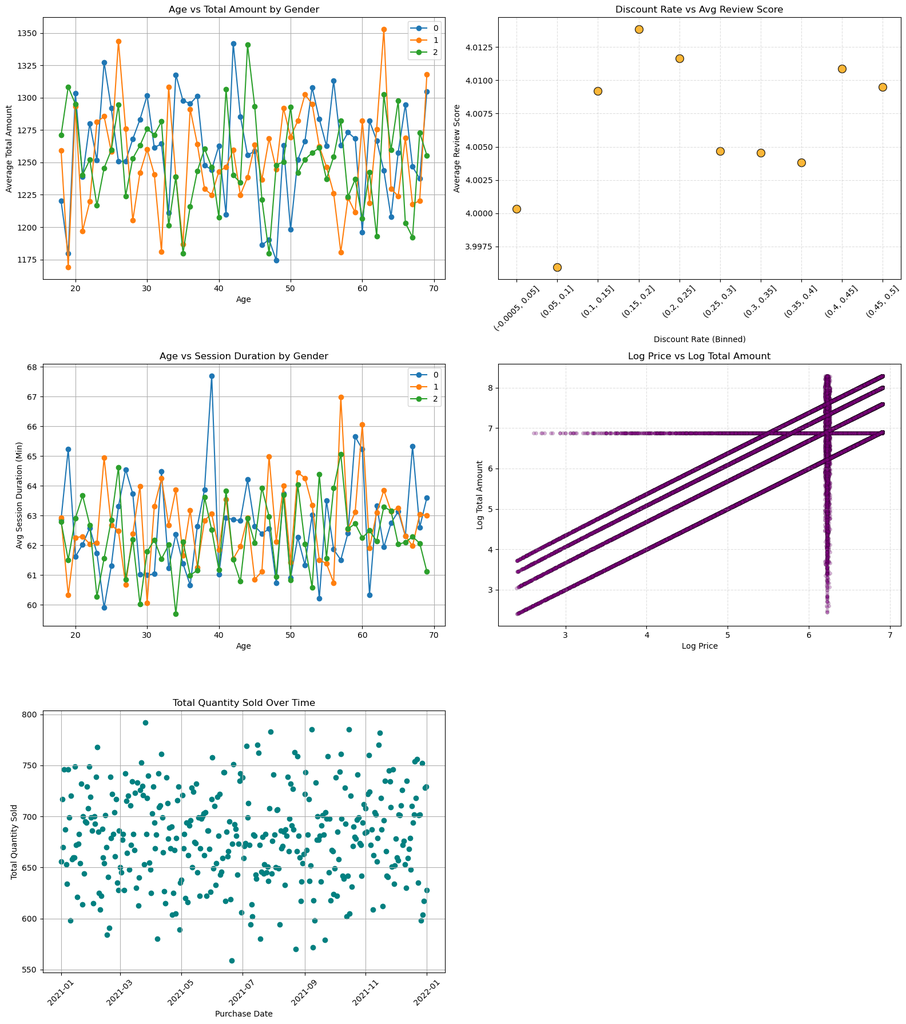

```python
fig, axes = plt.subplots(3, 2, figsize=(16, 18))
axes = axes.flatten()

grouped1 = df.groupby(['age', 'gender'])['totalamount'].mean().reset_index()
for g in grouped1['gender'].unique():
    subset = grouped1[grouped1['gender'] == g]
    axes[0].plot(subset['age'], subset['totalamount'], '-o', label=g, markersize=6)
axes[0].set_title("Age vs Total Amount by Gender")
axes[0].set_xlabel("Age")
axes[0].set_ylabel("Average Total Amount")
axes[0].legend()
axes[0].grid(True)

df['discount_bin'] = pd.cut(df['discountrate'], bins=10)
grouped2 = df.groupby('discount_bin', observed=True)['reviewscore'].mean().reset_index()
axes[1].scatter(range(len(grouped2)), grouped2['reviewscore'], marker='o',
                color='orange', s=100, edgecolor='black', alpha=0.8)
axes[1].set_title("Discount Rate vs Avg Review Score")
axes[1].set_xlabel("Discount Rate (Binned)")
axes[1].set_ylabel("Average Review Score")
axes[1].set_xticks(range(len(grouped2)))
axes[1].set_xticklabels(grouped2['discount_bin'], rotation=45)
axes[1].grid(True, linestyle='--', alpha=0.4)

grouped3 = df.groupby(['age', 'gender'])['sessionduration'].mean().reset_index()
for g in grouped3['gender'].unique():
    subset = grouped3[grouped3['gender'] == g]
    axes[2].plot(subset['age'], subset['sessionduration'], '-o', label=g, markersize=6)
axes[2].set_title("Age vs Session Duration by Gender")
axes[2].set_xlabel("Age")
axes[2].set_ylabel("Avg Session Duration (Min)")
axes[2].legend()
axes[2].grid(True)

axes[3].scatter(df.log_price, df.log_totalamount, marker='o', color='purple',
                s=20, alpha=0.3, edgecolor='black', linewidth=0.3)
axes[3].set_title("Log Price vs Log Total Amount")
axes[3].set_xlabel("Log Price")
axes[3].set_ylabel("Log Total Amount")
axes[3].grid(True, linestyle='--', alpha=0.4)

df['purchasedate'] = pd.to_datetime(df['purchasedate'], errors='coerce')
df_temp = df.dropna(subset=['purchasedate', 'quantity']).sort_values('purchasedate')
df_qty = df_temp.groupby('purchasedate')['quantity'].sum().reset_index()

axes[4].scatter(df_qty['purchasedate'], df_qty['quantity'], color='teal')
axes[4].set_title('Total Quantity Sold Over Time')
axes[4].set_xlabel('Purchase Date')
axes[4].set_ylabel('Total Quantity Sold')
axes[4].tick_params(axis='x', rotation=45)
axes[4].grid(True)

axes[5].axis('off')

plt.tight_layout()
plt.show()
```

### Bubble chart

#### 01. Analysis of Age vs. Total Amount, Discount Rate Effect, Age vs Session Duration, Discount vs Review Score, Age vs Spending and Price vs Satisfaction

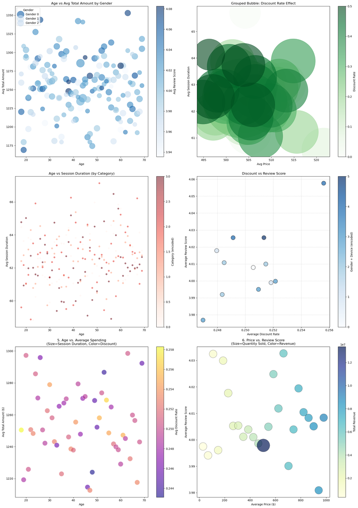

```python
fig, axes = plt.subplots(3, 2, figsize=(18, 25))
axes = axes.flatten()

grouped1 = df.groupby(['age', 'gender']).agg({
    'totalamount': 'mean', 'reviewscore': 'mean', 'quantity': 'sum'
}).reset_index()
for gender in grouped1['gender'].unique():
    subset = grouped1[grouped1['gender'] == gender]
    sizes = subset['quantity'] / subset['quantity'].max() * 800
    sc1 = axes[0].scatter(subset['age'], subset['totalamount'], c=subset['reviewscore'],
                          s=sizes, alpha=0.6, label=f"Gender {gender}", cmap='Blues')
fig.colorbar(sc1, ax=axes[0], label='Avg Review Score')
axes[0].set_title("Age vs Avg Total Amount by Gender")
axes[0].set_xlabel("Age")
axes[0].set_ylabel("Avg Total Amount")
axes[0].legend(title="Gender")

grouped2 = df.groupby('discountrate').agg({
    'sessionduration': 'mean', 'price': 'mean', 'quantity': 'sum'
}).reset_index()
sc2 = axes[1].scatter(grouped2['price'], grouped2['sessionduration'],
                      c=grouped2['discountrate'], s=grouped2['quantity'] * 5,
                      alpha=0.6, cmap='Greens')
fig.colorbar(sc2, ax=axes[1], label='Discount Rate')
axes[1].set_title("Grouped Bubble: Discount Rate Effect")
axes[1].set_xlabel("Avg Price")
axes[1].set_ylabel("Avg Session Duration")

grouped3 = df.groupby(['age', 'category']).agg({
    'sessionduration': 'mean', 'discountrate': 'mean'
}).reset_index()
sc3 = axes[2].scatter(grouped3['age'], grouped3['sessionduration'], c=pd.factorize(grouped3['category'])[0], s=grouped3['discountrate'] * 100, alpha=0.5, cmap='Reds')
fig.colorbar(sc3, ax=axes[2], label='Category (encoded)')
axes[2].set_title("Age vs Session Duration (by Category)")
axes[2].set_xlabel("Age")
axes[2].set_ylabel("Avg Session Duration")

grouped5 = df.groupby(['gender', 'devicetype']).agg({
    'discountrate': 'mean', 'reviewscore': 'mean', 'age': 'mean'
}).reset_index()
obj1 = pd.factorize(grouped5['gender'])[0] + pd.factorize(grouped5['devicetype'])[0]
sc5 = axes[3].scatter(grouped5['discountrate'], grouped5['reviewscore'], c=obj1, s=grouped5['age'] * 5, cmap='Blues', alpha=0.7, edgecolors='black')
fig.colorbar(sc5, ax=axes[3], label='Gender + Device (encoded)')
axes[3].set_title(" Discount vs Review Score")
axes[3].set_xlabel("Average Discount Rate")
axes[3].set_ylabel("Average Review Score")
axes[3].grid(True, linestyle='--', alpha=0.5)

age_summary = df.groupby('age').agg({
    'totalamount': 'mean',
    'sessionduration': 'mean',
    'discountrate': 'mean'
}).reset_index()
sc_new1 = axes[4].scatter(
    x=age_summary['age'],
    y=age_summary['totalamount'],
    s=age_summary['sessionduration'] * 5,
    c=age_summary['discountrate'],
    cmap='plasma', alpha=0.6, edgecolors='w'
)
fig.colorbar(sc_new1, ax=axes[4], label='Avg Discount Rate')
axes[4].set_title("5. Age vs. Average Spending\n(Size=Session Duration, Color=Discount)")
axes[4].set_xlabel("Age")
axes[4].set_ylabel("Avg Total Amount ($)")

df['price_bin'] = pd.cut(df['price'], bins=25)
price_summary = df.groupby('price_bin', observed=False).agg({
    'price': 'mean',
    'reviewscore': 'mean',
    'quantity': 'sum',
    'totalamount': 'sum'
}).dropna().reset_index()

sc_new2 = axes[5].scatter(
    x=price_summary['price'],
    y=price_summary['reviewscore'],
    s=price_summary['quantity'] * 0.08,
    c=price_summary['totalamount'],
    cmap='YlGnBu', alpha=0.7, edgecolors='k', linewidth=0.5
)
fig.colorbar(sc_new2, ax=axes[5], label='Total Revenue')
axes[5].set_title("6. Price vs. Review Score\n(Size=Quantity Sold, Color=Revenue)")
axes[5].set_xlabel("Average Price ($)")
axes[5].set_ylabel("Average Review Score")

plt.tight_layout()
plt.show()
```

#### 02.Avg Log Price vs Avg Log Total Amount

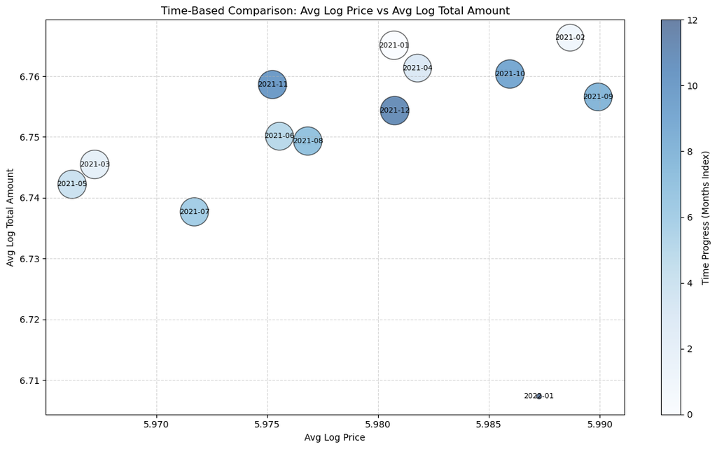

```python
df['purchasedate'] = pd.to_datetime(df['purchasedate'], errors='coerce')
df = df.dropna(subset=['purchasedate'])
df['month'] = df['purchasedate'].dt.to_period('M').astype(str)

grouped = df.groupby('month').agg({
    'log_price': 'mean',
    'log_totalamount': 'mean',
    'quantity': 'sum'
}).reset_index().sort_values('month')

x = grouped['log_price']
y = grouped['log_totalamount']
obj1 = grouped['month']
obj2 = (grouped['quantity'] / grouped['quantity'].max()) * 1000

plt.figure(figsize=(12, 7))
scatter = plt.scatter(x, y,
            c=range(len(obj1)),
            s=obj2,
            cmap='Blues',
            alpha=0.6,
            edgecolors='black')

for i, txt in enumerate(obj1):
    plt.annotate(txt, (x[i], y[i]), fontsize=8, ha='center', va='center')

plt.colorbar(scatter, label='Time Progress (Months Index)')
plt.title("Time-Based Comparison: Avg Log Price vs Avg Log Total Amount")
plt.xlabel("Avg Log Price")
plt.ylabel("Avg Log Total Amount")
plt.grid(True, linestyle='--', alpha=0.5)

plt.tight_layout()
plt.show()
```

### Line charts

#### 01. Average Total Amount by Age, Average Session Duration by Age, Average Product Price by Age, Average Review Score by Age, Average Discount Rate by Age and Average Purchase Quantity by Age

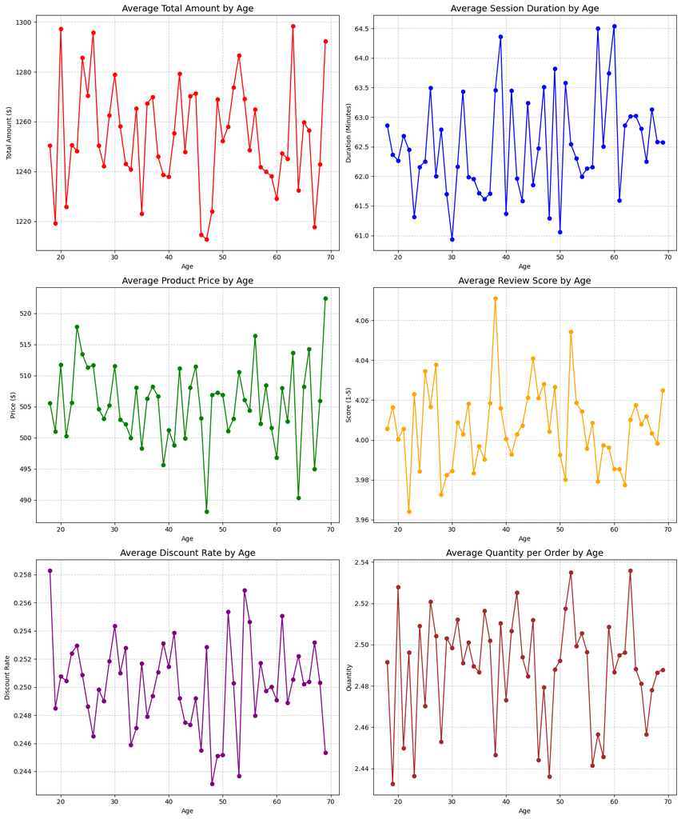

```python
fig, axes = plt.subplots(3, 2, figsize=(15, 18))
axes = axes.flatten()

metrics = [
    ('totalamount', 'red', 'Average Total Amount by Age', 'Total Amount ($)'),
    ('sessionduration', 'blue', 'Average Session Duration by Age', 'Duration (Minutes)'),
    ('price', 'green', 'Average Product Price by Age', 'Price ($)'),
    ('reviewscore', 'orange', 'Average Review Score by Age', 'Score (1-5)'),
    ('discountrate', 'purple', 'Average Discount Rate by Age', 'Discount Rate'),
    ('quantity', 'brown', 'Average Quantity per Order by Age', 'Quantity')
]

for i, (column, color, title, ylabel) in enumerate(metrics):

    eds = df.groupby('age')[column].mean().reset_index()

    axes[i].plot(eds['age'], eds[column], color=color, marker='o', linestyle='-')

    axes[i].set_title(title, fontsize=14)
    axes[i].set_xlabel('Age')
    axes[i].set_ylabel(ylabel)
    axes[i].grid(True, linestyle='--', alpha=0.7)

plt.tight_layout()
plt.show()
```

#### 02.Average Review Score Over Time

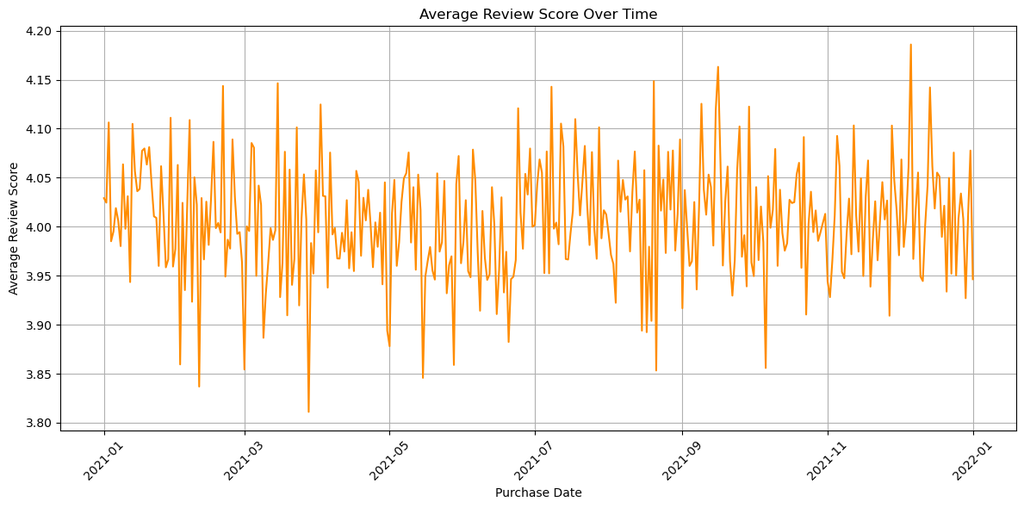

```python
df_review = df.groupby('purchasedate')['reviewscore'].mean().reset_index()

plt.figure(figsize=(12, 6))
plt.plot(df_review['purchasedate'], df_review['reviewscore'], color='darkorange', linestyle='-')

plt.xlabel('Purchase Date')
plt.ylabel('Average Review Score')
plt.title('Average Review Score Over Time')
plt.xticks(rotation=45)
plt.grid(True)
plt.tight_layout()
plt.show()
```

### Legends

#### 01. Analysis of Total Amount by Age, Session Duration by Age, Price Comparison by Age, Review Scores by Age, Discount & Quantity and Engagement Overview

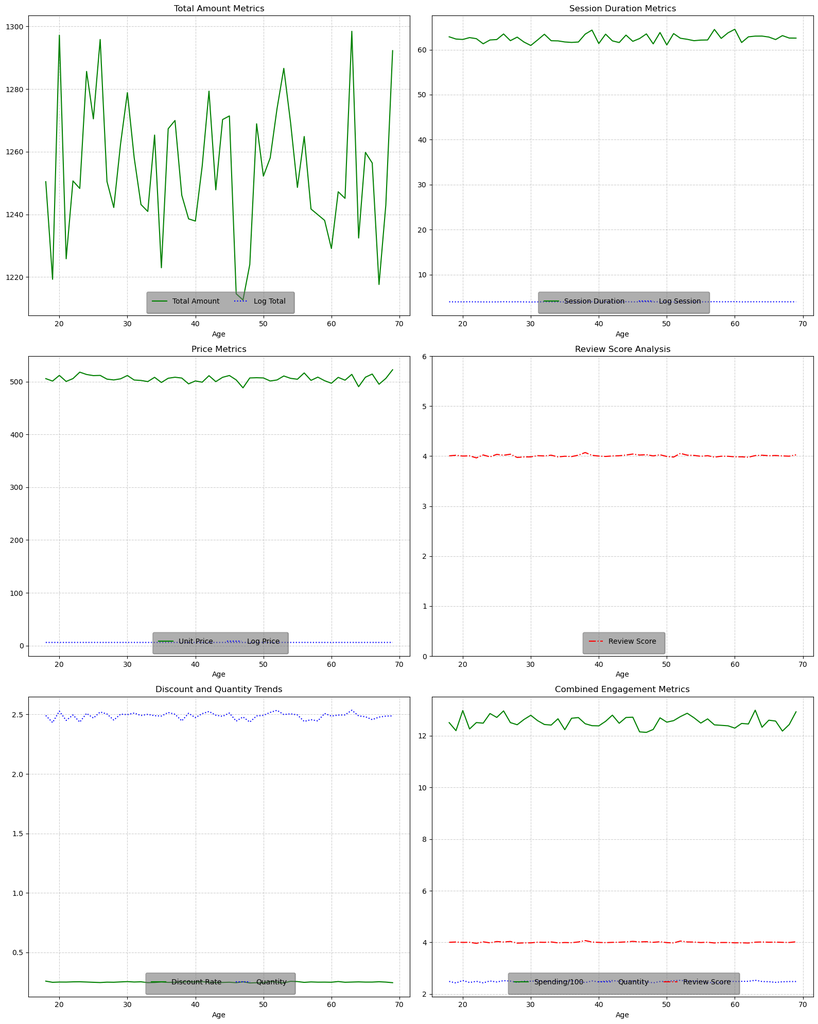

```python
slcd = df.groupby('age').mean(numeric_only=True).reset_index()

fig, axes = plt.subplots(3, 2, figsize=(16, 20))
axes = axes.flatten()
legend_style = dict(loc='lower center', frameon=True, ncol=3, borderpad=1, framealpha=0.1, shadow=True)

axes[0].plot(slcd['age'], slcd['totalamount'], '-g', label='Total Amount')
axes[0].plot(slcd['age'], slcd['log_totalamount'], ':b', label='Log Total')
axes[0].set_ylim(slcd['totalamount'].min() - 5, slcd['totalamount'].max() + 5)
axes[0].set_title('Total Amount Metrics')
axes[0].legend(**legend_style)

axes[1].plot(slcd['age'], slcd['sessionduration'], '-g', label='Session Duration')
axes[1].plot(slcd['age'], slcd['log_sessionduration'], ':b', label='Log Session')
axes[1].set_title('Session Duration Metrics')
axes[1].legend(**legend_style)

axes[2].plot(slcd['age'], slcd['price'], '-g', label='Unit Price')
axes[2].plot(slcd['age'], slcd['log_price'], ':b', label='Log Price')
axes[2].set_title('Price Metrics')
axes[2].legend(**legend_style)

axes[3].plot(slcd['age'], slcd['reviewscore'], '-.r', label='Review Score')
axes[3].set_ylim(0, 6)
axes[3].set_title('Review Score Analysis')
axes[3].legend(**legend_style)

axes[4].plot(slcd['age'], slcd['discountrate'], '-g', label='Discount Rate')
axes[4].plot(slcd['age'], slcd['quantity'], ':b', label='Quantity')
axes[4].set_title('Discount and Quantity Trends')
axes[4].legend(**legend_style)

axes[5].plot(slcd['age'], slcd['totalamount']/100, '-g', label='Spending/100')
axes[5].plot(slcd['age'], slcd['quantity'], ':b', label='Quantity')
axes[5].plot(slcd['age'], slcd['reviewscore'], '-.r', label='Review Score')
axes[5].set_title('Combined Engagement Metrics')
axes[5].legend(**legend_style)

for ax in axes:
    ax.grid(True, linestyle='--', alpha=0.6)
    ax.set_xlabel('Age')

plt.tight_layout()
plt.show()
```

#### 02. Price Metrics over Time

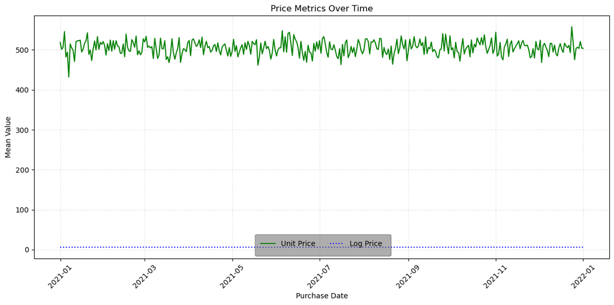

```python
df['purchasedate'] = pd.to_datetime(df['purchasedate'], errors='coerce')
df = df.dropna(subset=['purchasedate', 'price', 'log_price'])

slcd = df.groupby('purchasedate').mean(numeric_only=True).reset_index().sort_values('purchasedate')

plt.figure(figsize=(12, 6))

plt.plot(slcd['purchasedate'], slcd['price'], '-g', label='Unit Price')
plt.plot(slcd['purchasedate'], slcd['log_price'], ':b', label='Log Price')

plt.legend(
    loc='lower center',
    frameon=True,
    ncol=3,
    borderpad=1,
    framealpha=0.1,
    shadow=True
)

plt.title('Price Metrics Over Time')
plt.xlabel('Purchase Date')
plt.ylabel('Mean Value')
plt.xticks(rotation=45)

plt.grid(True, linestyle='--', alpha=0.3)
plt.tight_layout()
plt.show()
```

### Color Maps

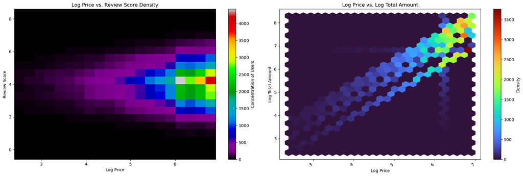

```python
fig, axes = plt.subplots(1, 2, figsize=(18, 6))
im1 = axes[0].hist2d(df['log_price'], df['reviewscore'],bins=20, cmap='nipy_spectral')
cbar1 = fig.colorbar(im1[-1], ax=axes[0])
cbar1.set_label('Concentration of Users')
axes[0].set_title('Log Price vs. Review Score Density')
axes[0].set_xlabel('Log Price')
axes[0].set_ylabel('Review Score')

hb2 = axes[1].hexbin(df['log_price'], df['log_totalamount'],gridsize=25, cmap='turbo')
cbar2 = fig.colorbar(hb2, ax=axes[1])
cbar2.set_label('Density')
axes[1].set_title('Log Price vs. Log Total Amount')
axes[1].set_xlabel('Log Price')
axes[1].set_ylabel('Log Total Amount')

plt.setp(axes[1].get_xticklabels(), rotation=30, ha='right')

plt.tight_layout()
plt.show()
```

# Data Visualization 02

```python
import pandas as pd
import numpy as np
import matplotlib.pyplot as plt
import seaborn as sns
from mpl_toolkits.axes_grid1.inset_locator import inset_axes
import matplotlib.dates as mdates
```

```python
df = pd.read_csv('cleaned_ecommerce_dataset.csv')
```

```python
print(df.columns)
```

```
Index(['userid', 'username', 'age', 'gender', 'country', 'signupdate',
       'productid', 'productname', 'category', 'price', 'purchasedate',
       'quantity', 'totalamount', 'hasdiscountapplied', 'discountrate',
       'reviewscore', 'reviewtext', 'lastlogin', 'sessionduration',
       'devicetype', 'referralsource', 'log_price', 'log_totalamount',
       'log_sessionduration'],
      dtype='object')
```

## Matplotlib plot

### 1. Scatter Plots

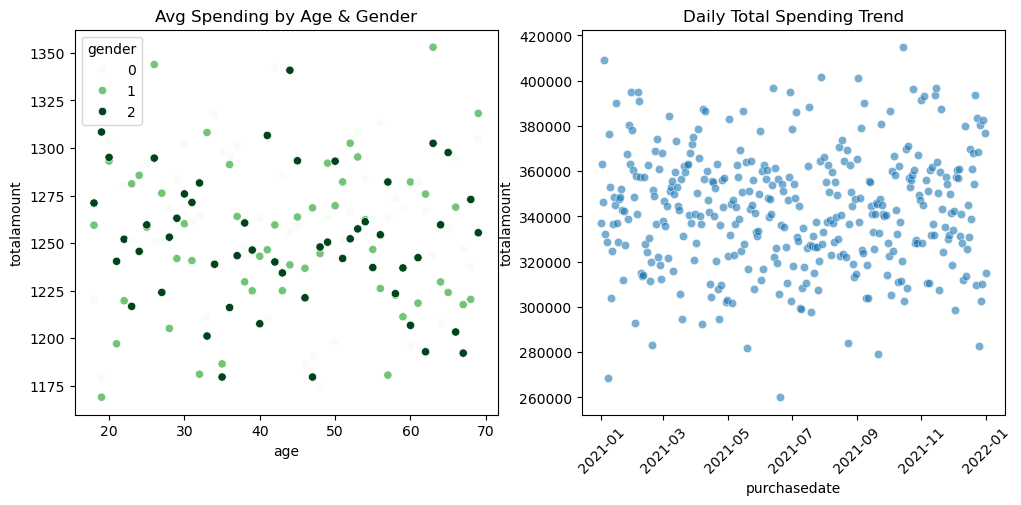

```python
plt.figure(figsize=(12, 5))
plt.subplot(1, 2, 1)
age_spending = df.groupby(['age', 'gender'])['totalamount'].mean().reset_index()
sns.scatterplot(data=age_spending, x='age', y='totalamount', hue='gender',palette='Greens')
plt.title("Avg Spending by Age & Gender")

df['purchasedate'] = pd.to_datetime(df['purchasedate'])
daily_spend = df.groupby('purchasedate')['totalamount'].sum().reset_index()
plt.subplot(1, 2, 2)
daily_sales = df.groupby('purchasedate')['totalamount'].sum().reset_index()
sns.scatterplot(data=daily_sales, x='purchasedate', y='totalamount', alpha=0.6)
plt.title("Daily Total Spending Trend")
plt.xticks(rotation=45)
plt.show()
```

### 2. Bar Plots

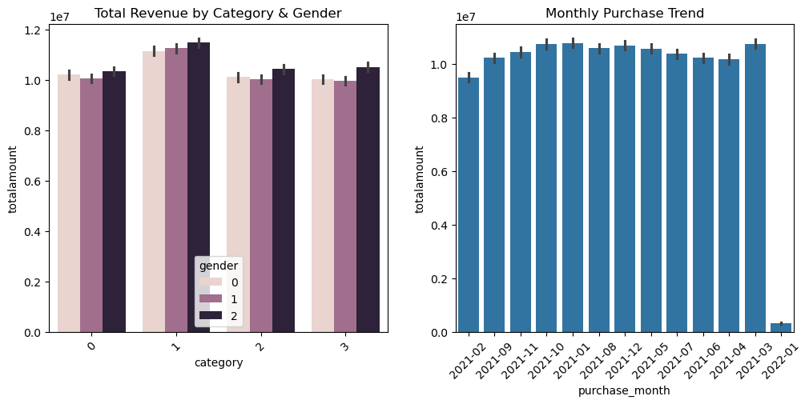

```python
plt.figure(figsize=(12, 5))
plt.subplot(1, 2, 1)
sns.barplot(data=df, x='category', y='totalamount', hue='gender', estimator=np.sum)
plt.title("Total Revenue by Category & Gender")
plt.xticks(rotation=45)

plt.subplot(1, 2, 2)
df['purchase_month'] = df['purchasedate'].dt.to_period('M').astype(str)
sns.barplot(data=df, x='purchase_month', y='totalamount', estimator=np.sum)
plt.title("Monthly Purchase Trend")
plt.xticks(rotation=45)
plt.show()
```

### 3. Swarm Plots

#### 01. Price distribution by Category

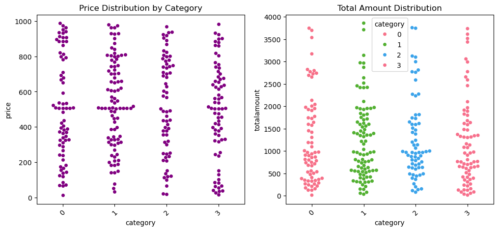

```python
df_sample = df.sample(300, random_state=42)
plt.figure(figsize=(12, 5))
plt.subplot(1, 2, 1)
sns.swarmplot(data=df_sample, x='category', y='price',color='Purple')
plt.title("Price Distribution by Category")
plt.xticks(rotation=45)

plt.subplot(1, 2, 2)
sns.swarmplot(data=df_sample, x='category', y='totalamount', hue='category', palette='husl')
plt.title("Total Amount Distribution")
plt.xticks(rotation=45)
plt.show()
```

### 4. Box Plots

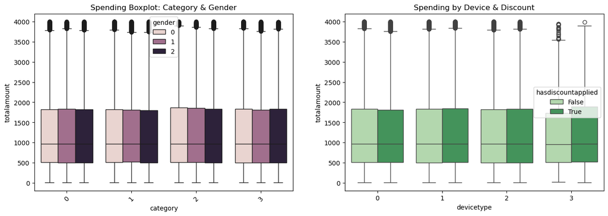

```python
plt.figure(figsize=(16, 5))
plt.subplot(1, 2, 1)
sns.boxplot(data=df, x='category', y='totalamount', hue='gender',)
plt.title("Spending Boxplot: Category & Gender")
plt.xticks(rotation=45)

plt.subplot(1, 2, 2)
sns.boxplot(data=df, x='devicetype', y='totalamount', hue='hasdiscountapplied',palette='Greens')
plt.title("Spending by Device & Discount")
plt.show()
```

### 5. Violin Plots

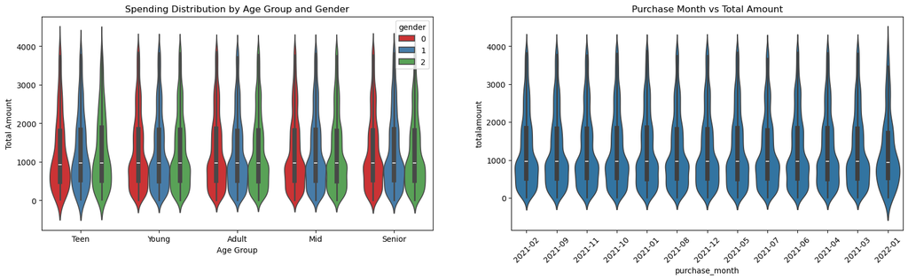

```python
plt.figure(figsize=(20, 5))
plt.subplot(1, 2,1)
df['age_group'] = pd.cut(df['age'], bins=[0, 18, 30, 45, 60, 100],
                         labels=['Teen', 'Young', 'Adult', 'Mid', 'Senior'])
sns.violinplot(
    data=df,
    x='age_group',
    y='totalamount',
    hue='gender',
    palette='Set1'
)
plt.title('Spending Distribution by Age Group and Gender')
plt.xlabel('Age Group')
plt.ylabel('Total Amount')
plt.xticks(rotation=0)

plt.subplot(1, 2,2)
df['purchase_month'] = df['purchasedate'].astype(str).str[:7]
sns.violinplot(data=df, x='purchase_month', y='totalamount')
plt.xticks(rotation=45)
plt.title("Purchase Month vs Total Amount")
plt.show()
plt.show()
```

## Histogram

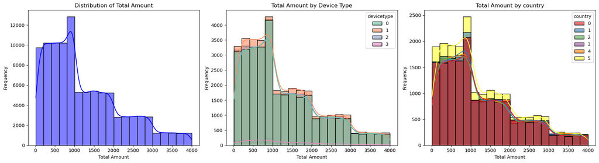

```python
plt.figure(figsize=(18, 5))
plt.subplot(1, 3, 1)
sns.histplot(df['totalamount'], bins=20, kde=True, color='blue')
plt.title("Distribution of Total Amount")
plt.xlabel("Total Amount")
plt.ylabel("Frequency")

plt.subplot(1, 3, 2)
sns.histplot(data=df, x='totalamount', hue='devicetype', bins=20, kde=True, palette='Set2', alpha=0.6)
plt.title("Total Amount by Device Type")
plt.xlabel("Total Amount")
plt.ylabel("Frequency")

plt.subplot(1, 3, 3)
sns.histplot(data=df, x='totalamount', hue='country', bins=20, kde=True, palette='Set1', alpha=0.6)
plt.title("Total Amount by country")
plt.xlabel("Total Amount")
plt.ylabel("Frequency")

plt.tight_layout()
plt.show()
```

## Pie Charts

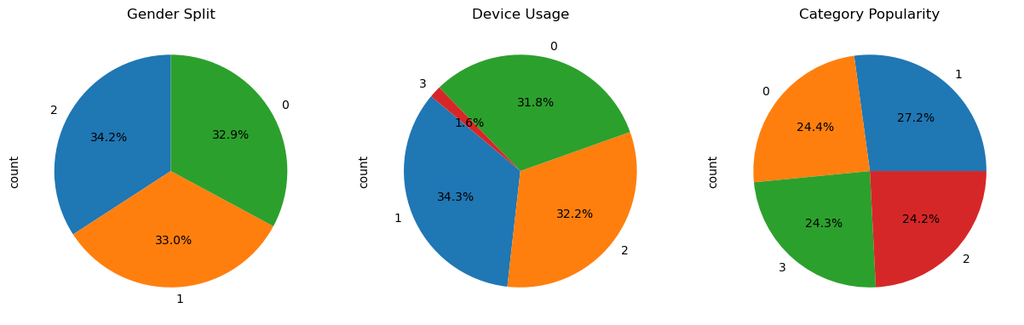

```python
plt.figure(figsize=(15, 5))
plt.subplot(1, 3, 1)
df['gender'].value_counts().plot.pie(autopct='%1.1f%%', startangle=90)
plt.title("Gender Split")

plt.subplot(1, 3, 2)
df['devicetype'].value_counts().plot.pie(autopct='%1.1f%%', startangle=140)
plt.title("Device Usage")

plt.subplot(1, 3, 3)
df['category'].value_counts().plot.pie(autopct='%1.1f%%')
plt.title("Category Popularity")
plt.show()
```

## Bar Charts

### 1. Vertical Bar Charts

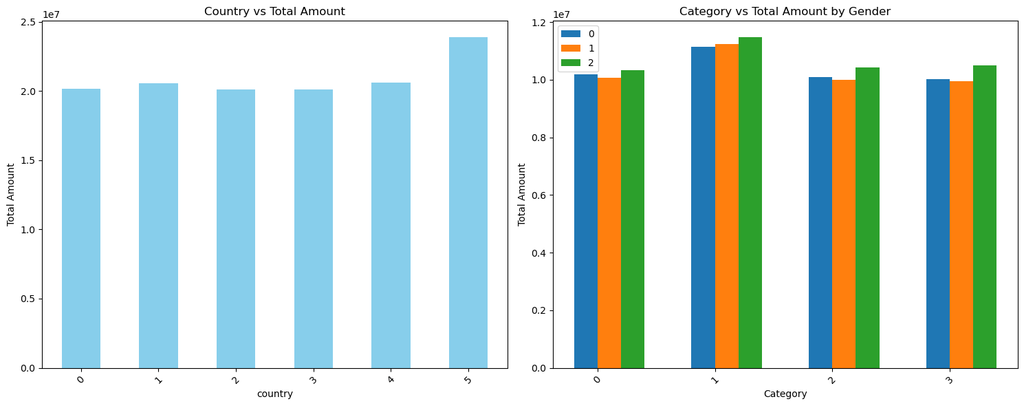

```python
plt.figure(figsize=(15, 6))

plt.subplot(1, 2, 1)
df.groupby('country')['totalamount'].sum().plot(kind='bar', color='skyblue')
plt.title("Country vs Total Amount")
plt.xticks(rotation=45)
plt.ylabel("Total Amount")

plt.subplot(1, 2, 2)
grouped = df.groupby(['category', 'gender'])['totalamount'].sum().unstack()
categories = grouped.index.tolist()
gender_list = grouped.columns.tolist()
x = np.arange(len(categories))
w = 0.20
for i, gender in enumerate(gender_list):
    plt.bar(x + i*w, grouped[gender], width=w, label=gender)
plt.xlabel("Category")
plt.ylabel("Total Amount")
plt.title("Category vs Total Amount by Gender")
plt.xticks(x + (w/2), categories, rotation=45)
plt.legend()

plt.tight_layout()
plt.show()
```

### 2. Horizontal Bar Charts

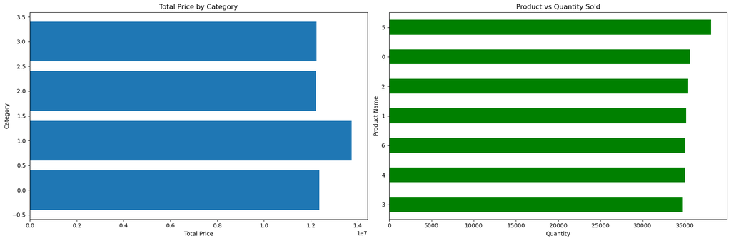

```python
plt.figure(figsize=(18, 6))

plt.subplot(1, 2, 1)
category_price = df.groupby('category')['price'].sum().sort_values()
plt.barh(category_price.index, category_price.values)
plt.title("Total Price by Category")
plt.xlabel("Total Price")
plt.ylabel("Category")

plt.subplot(1, 2, 2)
product_quantity = df.groupby('productname')['quantity'].sum().sort_values()
product_quantity.plot(kind='barh', color="green")
plt.title("Product vs Quantity Sold")
plt.xlabel("Quantity")
plt.ylabel("Product Name")

plt.tight_layout()
plt.show()
```

## Visualization Dashboard

```
KEY PERFORMANCE INDICATORS:
Total Sales: 125478954.72
Average Order Value: 1253.96
Total Orders: 100066
Unique Customers: 98036
Top Category: 1
```

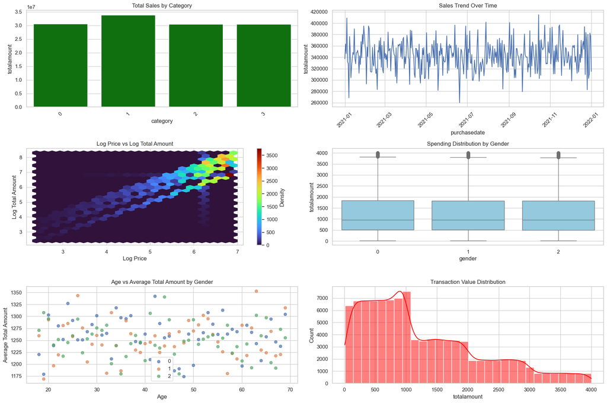

```python
sns.set(style="whitegrid")
plt.figure(figsize=(18, 12))

total_sales = df['totalamount'].sum()
avg_order_value = df['totalamount'].mean()
total_orders = df.shape[0]
unique_customers = df['userid'].nunique()
top_category = df.groupby('category')['totalamount'].sum().idxmax()
print("KEY PERFORMANCE INDICATORS:")
print("Total Sales:", round(total_sales, 2))
print("Average Order Value:", round(avg_order_value, 2))
print("Total Orders:", total_orders)
print("Unique Customers:", unique_customers)
print("Top Category:", top_category)


plt.subplot(3, 2, 1)
category_sales = df.groupby('category')['totalamount'].sum().reset_index()
sns.barplot(data=category_sales, x='category', y='totalamount',color="green")
plt.title("Total Sales by Category")
plt.xticks(rotation=45)


plt.subplot(3, 2, 2)
df['purchasedate'] = pd.to_datetime(df['purchasedate'])
time_sales = df.groupby(df['purchasedate'].dt.date)['totalamount'].sum().reset_index()
sns.lineplot(data=time_sales, x='purchasedate', y='totalamount')
plt.title("Sales Trend Over Time")
plt.xticks(rotation=45)


plt.subplot(3, 2, 3)
plt.hexbin(
    df['log_price'],
    df['log_totalamount'],
    gridsize=25,
    cmap='turbo'
)
plt.colorbar(label='Density')
plt.title("Log Price vs Log Total Amount")
plt.xlabel("Log Price")
plt.ylabel("Log Total Amount")


plt.subplot(3, 2, 4)
sns.boxplot(data=df, x='gender', y='totalamount',color="skyblue")
plt.title("Spending Distribution by Gender")


plt.subplot(3, 2, 5)
grouped = df.groupby(['age', 'gender'])['totalamount'].mean().reset_index()
for g in grouped['gender'].unique():
    subset = grouped[grouped['gender'] == g]
    plt.scatter(
        subset['age'],
        subset['totalamount'],
        alpha=0.7,
        label=g,
    )
plt.title("Age vs Average Total Amount by Gender")
plt.xlabel("Age")
plt.ylabel("Average Total Amount")
plt.legend()
plt.grid(True)


plt.subplot(3, 2, 6)
sns.histplot(df['totalamount'], bins=30, kde=True,color="red")
plt.title("Transaction Value Distribution")

plt.tight_layout()
plt.show()
```

# Statistical Analysis

```python
import numpy as np
import pandas as pd
from scipy import stats
from scipy.stats import chi2_contingency
from scipy.stats import f_oneway
```

```python
df = pd.read_csv("cleaned_ecommerce_dataset.csv")
```

```python
df.head()
```

|  | userid | username | age | gender | country | signupdate | productid | productname | category | price | ... | discountrate | reviewscore | reviewtext | lastlogin | sessionduration | devicetype | referralsource | log_price | log_totalamount | log_sessionduration |
| --- | --- | --- | --- | --- | --- | --- | --- | --- | --- | --- | --- | --- | --- | --- | --- | --- | --- | --- | --- | --- | --- |
| 0 | 1.0 | 0 | 39.0 | 1 | 4 | 2021-02-01 | 8190.0 | 3 | 2 | 532.37 | ... | 0.02 | 5.1 | Excellent | 1356 days 07:32:32.318694680 | 45.02 | 1 | 3 | 6.279215 | 6.279215 | 3.829076 |
| 1 | 2.0 | 10780 | 25.0 | 0 | 1 | 2020-12-04 | 9527.0 | 5 | 0 | 848.83 | ... | 0.29 | 5.1 | Excellent | 2722 days 23:32:32.318717680 | 13.83 | 1 | 3 | 6.745036 | 6.745036 | 2.696652 |
| 2 | 3.0 | 21564 | 43.0 | 2 | 1 | 2022-07-08 | 3299.0 | 1 | 1 | 64.88 | ... | 0.03 | 3.2 | Good | 2293 days 19:32:32.318722680 | 59.09 | 2 | 2 | 4.187835 | 4.873364 | 4.095843 |
| 3 | 4.0 | 32361 | 44.0 | 1 | 2 | 2021-06-07 | 8795.0 | 5 | 1 | 465.08 | ... | 0.23 | 4.3 | Good | 556 days 07:32:32.318726680 | 55.42 | 0 | 1 | 6.144357 | 6.836431 | 4.032824 |
| 4 | 5.0 | 43128 | 23.0 | 0 | 1 | 2021-11-06 | 1389.0 | 3 | 2 | 331.82 | ... | 0.02 | 5.1 | Average | 2185 days 11:32:32.318730680 | 14.99 | 2 | 1 | 5.807602 | 5.807602 | 2.771964 |

5 rows × 24 columns

```python
df.info()
```

```
<class 'pandas.core.frame.DataFrame'>
RangeIndex: 100066 entries, 0 to 100065
Data columns (total 24 columns):
 #   Column               Non-Null Count   Dtype
---  ------               --------------   -----
 0   userid               100066 non-null  float64
 1   username             100066 non-null  int64
 2   age                  100066 non-null  float64
 3   gender               100066 non-null  int64
 4   country              100066 non-null  int64
 5   signupdate           100066 non-null  object
 6   productid            100066 non-null  float64
 7   productname          100066 non-null  int64
 8   category             100066 non-null  int64
 9   price                100066 non-null  float64
```

[output cut: 16 more lines]

```python
df.shape
```

```
(100066, 24)
```

## Summary Statistics

```python
df.describe()
```

|  | userid | username | age | gender | country | productid | productname | category | price | quantity | totalamount | discountrate | reviewscore | sessionduration | devicetype | referralsource | log_price | log_totalamount | log_sessionduration |
| --- | --- | --- | --- | --- | --- | --- | --- | --- | --- | --- | --- | --- | --- | --- | --- | --- | --- | --- | --- |
| count | 100066.000000 | 100066.000000 | 100066.000000 | 100066.000000 | 100066.000000 | 100066.000000 | 100066.000000 | 100066.000000 | 100066.000000 | 100066.000000 | 100066.000000 | 100066.000000 | 100066.000000 | 100066.000000 | 100066.000000 | 100066.000000 | 100066.000000 | 100066.000000 | 100066.000000 |
| mean | 49997.693282 | 47416.584804 | 43.452361 | 1.013011 | 2.572912 | 5509.384266 | 3.025163 | 1.483271 | 505.367851 | 2.488318 | 1253.961932 | 0.250120 | 4.006588 | 62.505494 | 1.037205 | 1.457708 | 5.978264 | 6.753682 | 3.960757 |
| std | 28867.557718 | 28439.538926 | 14.790085 | 0.818642 | 1.734460 | 2605.984191 | 2.003372 | 1.105735 | 275.847630 | 1.108219 | 952.894550 | 0.141252 | 0.979517 | 34.829797 | 0.839444 | 1.127000 | 0.849816 | 1.010550 | 0.695512 |
| min | 1.000000 | 0.000000 | 18.000000 | 0.000000 | 0.000000 | 1000.000000 | 0.000000 | 0.000000 | 10.000000 | 1.000000 | 10.020000 | 0.000000 | -0.600000 | 5.000000 | 0.000000 | 0.000000 | 2.397895 | 2.399712 | 1.791759 |
| 25% | 24996.250000 | 22137.250000 | 31.000000 | 0.000000 | 1.000000 | 3230.000000 | 1.000000 | 1.000000 | 275.817500 | 2.000000 | 508.002500 | 0.130000 | 3.400000 | 35.250000 | 0.000000 | 0.000000 | 5.623358 | 6.232453 | 3.590439 |
| 50% | 49997.500000 | 47137.500000 | 43.000000 | 1.000000 | 3.000000 | 5524.000000 | 3.000000 | 1.000000 | 505.285000 | 2.000000 | 967.060000 | 0.250000 | 4.000000 | 62.460000 | 1.000000 | 1.000000 | 6.227100 | 6.875294 | 4.150410 |
| 75% | 74996.750000 | 72133.750000 | 56.000000 | 2.000000 | 4.000000 | 7775.000000 | 5.000000 | 2.000000 | 734.520000 | 3.000000 | 1828.380000 | 0.370000 | 4.600000 | 89.660000 | 2.000000 | 2.000000 | 6.600578 | 7.511732 | 4.507116 |
| max | 100000.000000 | 97138.000000 | 69.000000 | 2.000000 | 5.000000 | 9998.000000 | 6.000000 | 3.000000 | 999.980000 | 4.000000 | 3999.720000 | 0.500000 | 8.600000 | 3000.000000 | 3.000000 | 3.000000 | 6.908735 | 8.294230 | 8.006701 |

### 01. Central Tendency

```python
mean_values = df.mean(numeric_only=True)
print("Mean:\n", mean_values)
```

```
Mean:
 userid                 49997.693282
username               47416.584804
age                       43.452361
gender                     1.013011
country                    2.572912
productid               5509.384266
productname                3.025163
category                   1.483271
price                    505.367851
quantity                   2.488318
totalamount             1253.961932
hasdiscountapplied         0.493974
discountrate               0.250120
reviewscore                4.006588
sessionduration           62.505494
devicetype                 1.037205
referralsource             1.457708
log_price                  5.978264
log_totalamount            6.753682
log_sessionduration        3.960757
dtype: float64
```

```python
median_values = df.median(numeric_only=True)
print("Median:\n", median_values)
```

```
Median:
 userid                 49997.500000
username               47137.500000
age                       43.000000
gender                     1.000000
country                    3.000000
productid               5524.000000
productname                3.000000
category                   1.000000
price                    505.285000
quantity                   2.000000
totalamount              967.060000
hasdiscountapplied         0.000000
discountrate               0.250000
reviewscore                4.000000
sessionduration           62.460000
devicetype                 1.000000
referralsource             1.000000
log_price                  6.227100
log_totalamount            6.875294
log_sessionduration        4.150410
dtype: float64
```

```python
mode_values = df.mode(numeric_only=True).iloc[0]
print("Mode:\n", mode_values)
```

```
Mode:
 userid                    931.0
username                 8333.0
age                        43.0
gender                      2.0
country                     5.0
productid                6909.0
productname                 5.0
category                    1.0
price                   505.285
quantity                    2.0
totalamount              967.06
hasdiscountapplied        False
discountrate               0.25
reviewscore                 4.0
sessionduration           62.46
devicetype                  1.0
referralsource              0.0
log_price                6.2271
log_totalamount        6.875294
log_sessionduration     4.15041
Name: 0, dtype: object
```

### 02. Measures of position

```python
df_numeric = df.select_dtypes(include=[np.number])
Q1 = df_numeric.quantile(0.25)
print("Q1:\n", Q1)
```

```
Q1:
 userid                 24996.250000
username               22137.250000
age                       31.000000
gender                     0.000000
country                    1.000000
productid               3230.000000
productname                1.000000
category                   1.000000
price                    275.817500
quantity                   2.000000
totalamount              508.002500
discountrate               0.130000
reviewscore                3.400000
sessionduration           35.250000
devicetype                 0.000000
referralsource             0.000000
log_price                  5.623358
log_totalamount            6.232453
log_sessionduration        3.590439
Name: 0.25, dtype: float64
```

```python
Q2 = df_numeric.quantile(0.50)
print("Q2 (Median):\n", Q2)
```

```
Q2 (Median):
 userid                 49997.500000
username               47137.500000
age                       43.000000
gender                     1.000000
country                    3.000000
productid               5524.000000
productname                3.000000
category                   1.000000
price                    505.285000
quantity                   2.000000
totalamount              967.060000
discountrate               0.250000
reviewscore                4.000000
sessionduration           62.460000
devicetype                 1.000000
referralsource             1.000000
log_price                  6.227100
log_totalamount            6.875294
log_sessionduration        4.150410
Name: 0.5, dtype: float64
```

```python
Q3 = df_numeric.quantile(0.75)
print("Q3:\n", Q3)
```

```
Q3:
 userid                 74996.750000
username               72133.750000
age                       56.000000
gender                     2.000000
country                    4.000000
productid               7775.000000
productname                5.000000
category                   2.000000
price                    734.520000
quantity                   3.000000
totalamount             1828.380000
discountrate               0.370000
reviewscore                4.600000
sessionduration           89.660000
devicetype                 2.000000
referralsource             2.000000
log_price                  6.600578
log_totalamount            7.511732
log_sessionduration        4.507116
Name: 0.75, dtype: float64
```

### 03. Measures of variability

```python
variance = df.var(numeric_only=True)
print("Variance:\n", variance)
```

```
Variance:
 userid                 8.333359e+08
username               8.088074e+08
age                    2.187466e+02
gender                 6.701750e-01
country                3.008350e+00
productid              6.791154e+06
productname            4.013498e+00
category               1.222650e+00
price                  7.609191e+04
quantity               1.228150e+00
totalamount            9.080080e+05
hasdiscountapplied     2.499662e-01
discountrate           1.995211e-02
reviewscore            9.594531e-01
sessionduration        1.213115e+03
devicetype             7.046668e-01
referralsource         1.270130e+00
log_price              7.221880e-01
log_totalamount        1.021212e+00
log_sessionduration    4.837364e-01
dtype: float64
```

```python
std_dev = df.std(numeric_only=True)
print("Standard Deviation:\n", std_dev)
```

```
Standard Deviation:
 userid                 28867.557718
username               28439.538926
age                       14.790085
gender                     0.818642
country                    1.734460
productid               2605.984191
productname                2.003372
category                   1.105735
price                    275.847630
quantity                   1.108219
totalamount              952.894550
hasdiscountapplied         0.499966
discountrate               0.141252
reviewscore                0.979517
sessionduration           34.829797
devicetype                 0.839444
referralsource             1.127000
log_price                  0.849816
log_totalamount            1.010550
log_sessionduration        0.695512
dtype: float64
```

```python
range_values = df_numeric.max() - df_numeric.min()
print("Range:\n", range_values)
```

```
Range:
 userid                 99999.000000
username               97138.000000
age                       51.000000
gender                     2.000000
country                    5.000000
productid               8998.000000
productname                6.000000
category                   3.000000
price                    989.980000
quantity                   3.000000
totalamount             3989.700000
discountrate               0.500000
reviewscore                9.200000
sessionduration         2995.000000
devicetype                 3.000000
referralsource             3.000000
log_price                  4.510840
log_totalamount            5.894518
log_sessionduration        6.214941
dtype: float64
```

## Hypothesis Testing

### 01. Welch’s t-test

#### Question: Is there a significant difference in the average total purchase amount between customers who received a discount and those who did not receive a discount?

- μ₁ = mean TotalAmount (discount applied)
- μ₂ = mean TotalAmount (no discount applied)

##### Hypotheses:

- H₀: μ₁ = μ₂ (There is no significant difference in the mean total purchase amount between customers with and without discounts.)
- H₁: μ₁ ≠ μ₂ (There is a significant difference in the mean total purchase amount between customers with and without discounts.)

```python
discount_yes = df[df['hasdiscountapplied'] == True]['totalamount']
discount_no = df[df['hasdiscountapplied'] == False]['totalamount']
t_stat, p_value = stats.ttest_ind(discount_yes, discount_no, equal_var=False)

print("T-statistic:", t_stat)
print("P-value:", p_value)
```

```
T-statistic: 0.07989808208106651
P-value: 0.936318475097587
```

```python
if p_value < 0.05:
    print("Reject H0: Spending differs with discount")
else:
    print("Fail to Reject H0")
```

```
Fail to Reject H0
```

### 02. Chi-Square Test (Using gender & category)

#### Question:Is there a significant association between gender and product category preference?

- μ₁ = Gender
- μ₂ = Category

##### Hypotheses:

- H₀:μ₁ = μ₂ (There is no significant association between gender and product category.)

H₁: μ₁ ≠ μ₂ (There is a significant association between gender and product category.)

```python
table = pd.crosstab(df['gender'], df['category'])
chi2, p_value, dof, expected = chi2_contingency(table)

print("Chi2-statistic:", chi2)
print("P-value:", p_value)
print("Degrees of freedom:", dof)
```

```
Chi2-statistic: 4.372440075879161
P-value: 0.6264110260877367
Degrees of freedom: 6
```

```python
if p_value < 0.05:
    print("Reject H0: Gender and category are related")
else:
    print("Fail to Reject H0")
```

```
Fail to Reject H0
```

### 03. ANOVA (F-Test) – Total Amount by Category

#### Question: Is there a significant difference in the average total purchase amount among different product categories?

- μ₁ = mean TotalAmount for Category 1
- μ₂ = mean TotalAmount for Category 2
- μ₃ = mean TotalAmount for Category 3
- μ₄ = mean TotalAmount for Category 4

##### Hypotheses:

- H₀: μ₁ = μ₂ = μ₃ = μ₄ (There is no significant difference in mean total purchase amount among product categories.)
- H₁: μ₁ ≠ μ₂ ≠ μ₃ ≠ μ₄ (At least one category mean is different from the others.)

```python
groups = [group['totalamount'] for name, group in df.groupby('category')]
f_stat, p_value = stats.f_oneway(*groups)
print("F-statistic:", f_stat)
print("P-value:", p_value)
```

```
F-statistic: 1.1808943060560226
P-value: 0.31527408637121135
```

```python
if p_value < 0.05:
    print("Reject H0: Total amount differs by category")
else:
    print("Fail to Reject H0: No significant difference by category")
```

```
Fail to Reject H0: No significant difference by category
```